# mod_1_final

## Quantum Computing Project Work - mod 1

```python
try:
  import google.colab
  IN_COLAB = True
except:
  IN_COLAB = False
if IN_COLAB:
    import subprocess
    subprocess.call(['pip', 'install', 'qiskit'])
    subprocess.call(['pip', 'install', 'numpy'])
    subprocess.call(['pip', 'install', 'matplotlib'])
    subprocess.call(['pip', 'install', 'psutil'])
import math
from qiskit import *
import numpy as np
from math import gcd
from qiskit.visualization import plot_histogram
import matplotlib.pyplot as plt
from fractions import Fraction
import psutil as ps
import pandas as pd
from qiskit.quantum_info import Statevector

shots=1000
```

### Shor's Algorithm

Factoring large integers is a difficult problem for classical computers. In fact, the best known classical algorithms have a runtime that grows exponentially with the size of the integer to be factored, which makes it impractical for large numbers. This is a problem for cryptographic systems that rely on the difficulty of factoring large integers, such as RSA.

#### Steps:

1. Pick a random number 1 < $a$ < $N$.
2. Compute $K$ = gcd ( $a$ , $N$ ), the greatest common divisor of $a$ and $N$.
3. If $K ≠ 1$, then $K$ is a nontrivial factor of $N$, so we are done.
4. Otherwise, use the **quantum period-finding** subroutine to find $r$, which denotes the period of the following function: $f ( x ) = a^{x} ( \bmod N )$ .

   Equivalently, $r$ is the smallest positive integer that satisfies $a^{r} ≡ 1 ( \bmod N )$.
5. If $r$ is odd, then go back to step 1.
6. Otherwise, both gcd ( $a^{r / 2}$ + 1 , $N$ )or gcd ( $a^{r / 2}$ − 1 , $N$ ) are nontrivial factors of $N$, so we are done.

#### Period Finding Solutions

Shor’s solution was to use quantum phase estimation on the unitary operator:

$$ U|y\rangle \equiv |ay \bmod N \rangle $$ [qiskit]: https://qiskit.org/textbook/ch-algorithms/shor.html#4.-Modular-Exponentiation

So a superposition of the states in this cycle ($|u_0\rangle$) would be an eigenstate of $U$:

$$|u_0\rangle = \tfrac{1}{\sqrt{r}}\sum_{k=0}^{r-1}{|a^k \bmod N\rangle} $$

This eigenstate has an eigenvalue of 1, which isn’t very interesting. A more interesting eigenstate could be one in which the phase is different for each of these computational basis states. Specifically, let’s look at the case in which the phase of the $k$ th state is proportional to $k$:

$$\begin{aligned} |u_1\rangle &= \tfrac{1}{\sqrt{r}}\sum_{k=0}^{r-1}{e^{-\tfrac{2\pi i k}{r}}|a^k \bmod N\rangle}\\[10pt] U|u_1\rangle &= e^{\tfrac{2\pi i}{r}}|u_1\rangle \end{aligned} $$

This is a particularly interesting eigenvalue as it contains $r$. In fact, $r$ has to be included to make sure the phase differences between the $r$ computational basis states are equal. This is not the only eigenstate with this behaviour; to generalise this further, we can multiply an integer, $s$, to this phase difference, which will show up in our eigenvalue:

$$\begin{aligned} |u_s\rangle &= \tfrac{1}{\sqrt{r}}\sum_{k=0}^{r-1}{e^{-\tfrac{2\pi i s k}{r}}|a^k \bmod N\rangle}\\[10pt] U|u_s\rangle &= e^{\tfrac{2\pi i s}{r}}|u_s\rangle \end{aligned} $$

We now have a unique eigenstate for each integer value of $s$ where $$0 \leq s \leq r-1.$$ Very conveniently, if we sum up all these eigenstates, the different phases cancel out all computational basis states except $|1\rangle$:

$$ \tfrac{1}{\sqrt{r}}\sum_{s=0}^{r-1} |u_s\rangle = |1\rangle$$

Since the computational basis state $|1\rangle$ is a superposition of these eigenstates, which means if we do QPE on $U$ using the state $|1\rangle$, we will measure a phase:

$$\phi = \frac{s}{r}$$

Where $s$ is a random integer between $0$ and $r-1$. We finally use the [continued fractions](https://en.wikipedia.org/wiki/Continued_fraction) algorithm on $\phi$ to find $r$.

#### Conclusion

When we have obtained $r$, we might be able to use this to find a factor of $N$. Since:

$$a^r \bmod N = 1 $$

then:

$$(a^r - 1) \bmod N = 0 $$

which means $N$ must divide $a^r-1$. And if $r$ is also even, then we can write:

$$a^r -1 = (a^{r/2}-1)(a^{r/2}+1)$$

(if $r$ is not even, we cannot go further and must try again with a different value for $a$). There is then a high probability that the greatest common divisor of $N$ and either $a^{r/2}-1$, or $a^{r/2}+1$ is a proper factor of $N$.

#### Quiskit implementation

All online tutorial on Shor's Algorithm uses 15 as N. Since this is a project i want to change N and consequently also the U module.

I found a [paper](https://arxiv.org/pdf/quant-ph/0205095.pdf) about general circuit that should not rely on any property of N, but it is non-trival.

```python
N = 21
m = int(math.log2(N)+1)     # number of qbit used to represent x
t = m                       # number of counting qubits; using higher qubits for counting involves more precision in phase estimation
a = 2                       # our guess number such that g^(p/2)+-1 should have cm with N
print('I\'ll use {} qubits circuit'.format(m+t))
```

```
I'll use 10 qubits circuit
```

First we need to create the Unitary function that compute 2^x mod N

"*it is clear that the registers become highly entangled with each other: since U is a function of C and N , the entangling operation is unique to each problem.*" [ref](https://arxiv.org/pdf/0705.1398.pdf)

```python
def c_2mod21(pow):
    """U operator for 2 mod 21"""
    U = QuantumCircuit(5)
    # Since there is not trivial general circuit that compute a^x mod N,
    # this is the specific one that perform 2^x mod 21 and verify with a f
    for _ in range(pow):
        U.cswap(0,1,2)
        U.cswap(0,3,4)
        U.cx(4, 0)
        U.cx(4, 2)
        U.swap(3,4)
        U.swap(0,3)
        U.swap(3,2)
        U.swap(2,1)
    U.name = "2^%i mod 21" % (pow)
    #if verify(U,a,N): print('Verified')
    U=U.to_gate()
    c_U = U.control()
    return c_U

def verify(circuit,a,N):
    i = 1
    cnt=0
    while(i != 1 and cnt > 1):
        print("Apply %s, %i times: %i" % (circuit.name, cnt, i))
        sv = Statevector.from_int(i, 32)  # 32 is no. of elements in vector (dimension)
        sv = sv.evolve(circuit)
        output = sv.sample_memory(1)[0]  # simulate one shot (circuit is deterministic)
        if i != (a**cnt % N) : return False # i'm not checking if the mod is goo
        i = int(output, 2)
        cnt+=1
    return True
```

Then implement inverse QFT circuit:

```python
def qft_dagger(n):
    """n-qubit QFTdagger the first n qubits in circ"""
    qc = QuantumCircuit(n)
    # Don't forget the Swaps!
    for qubit in range(n//2):
        qc.swap(qubit, n-qubit-1)
    for j in range(n):
        for m in range(j):
            qc.cp(-np.pi/float(2**(j-m)), m, j)
        qc.h(j)
    qc.name = "QFT†"
    return qc
```

And finally all Quantum Phase Estimation circuit, using U and QFT-¹:

```python
def qpe_2mod21(m,t,a):
    qc = QuantumCircuit(t+m, t)
    for q in range(t):
        qc.h(q)             # Initialize counting qubits in state |+>
    qc.x(t)                 # and the register of |psi> in |1>
    for q in range(t):      # Do controlled-U operations
        qc.append(c_2mod21(2**q),
                 [q] + [i+t for i in range(m)])
    qc.append(qft_dagger(t), range(t)) # Do inverse-QFT
    qc.measure(range(t), range(t))
    # Simulate Results
    aer_sim = Aer.get_backend('aer_simulator')
    # Setting memory=True below allows us to see a list of each sequential reading
    t_qc = transpile(qc, aer_sim)
    qobj = assemble(t_qc, shots=shots)
    result = aer_sim.run(qobj, memory=True).result()
    counts = result.get_counts()
    readings = result.get_memory()
    print("Register Reading: " + readings[0])
    phase = int(readings[0],2)/(2**t)
    print("Corresponding Phase: %f" % phase)
    return phase,qc,counts
```

```python
def find_factor():
    factor_found = False
    attempt = 0
    factor= []
    while not factor_found:
        attempt += 1
        print("\nAttempt %i:" % attempt)
        phase,qc,counts = qpe_2mod21(m,t,a) # Phase = s/r
        frac = Fraction(phase).limit_denominator(N) # Denominator should (hopefully!) tell us r
        r = frac.denominator
        print("Result: r = %i" % r)
        if phase != 0:
            # Guesses for factors are gcd(x^{r/2} ±1 , 15)
            guesses = [gcd(a**(r//2)-1, N), gcd(a**(r//2)+1, N)]
            print("Guessed Factors: %i and %i" % (guesses[0], guesses[1]))
            for guess in guesses:
                if guess not in [1,N] and (N % guess) == 0: # Check to see if guess is a factor
                    print("*** Non-trivial factor found: %i ***" % guess)
                    factor.append(guess)
                    factor_found = True
            if (len(factor) == 1): factor.append(int(N/factor[0]))
    return factor,counts,qc
factor,counts,qc=find_factor()
print(factor)
```

```
Attempt 1:
Register Reading: 11011
Corresponding Phase: 0.843750
Result: r = 19
Guessed Factors: 7 and 3
*** Non-trivial factor found: 7 ***
*** Non-trivial factor found: 3 ***
[7, 3]
```

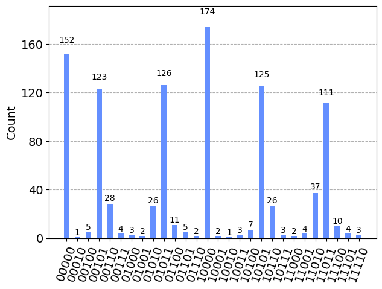

```python
plot_histogram(counts)
```

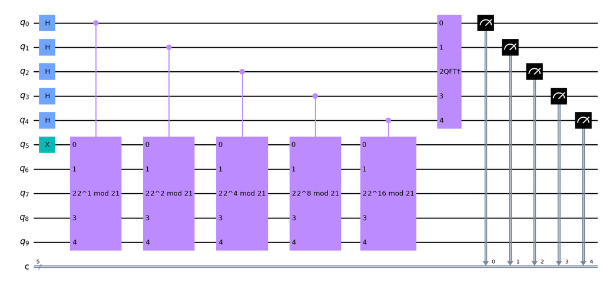

```python
qc.draw('mpl',fold=-1)
```

### RSA

RSA (Rivest-Shamir-Adleman) is an asymmetric cryptography algorithm used for secure communication. The algorithm uses two keys, a public key and a private key, to encrypt and decrypt messages. The public key can be shared without compromising security, while the private key must be kept secret.

#### Variables

The variables used in RSA are:

- $p$ and $q$: two distinct prime numbers
- $n$: the product of $p$ and $q$
- $e$: a random integer between 1 and $\varphi(n)$ that is coprime to $\varphi(n)$
- $d$: an integer between 1 and $\varphi(n)$ such that ed ≡ 1 (mod $\varphi(n)$)
- $(e, n)$: is the **public key**
- $(d, n)$: is the **private key**

#### Formulas

The formulas used in RSA are as follows:

- n = pq
- $\varphi(n) = (p-1)(q-1)$
- ed ≡ 1 (mod $\varphi(n)$)
- To encrypt a message: $C = M^e (\bmod n)$
- To decrypt the cipher: $M = C^d (\bmod n)$.

### Full Implementation

In the full implementation i found a problem using small prime numbers. Since $N=p*q$ is very small (21) i need to use message whose characters have ASCII codes smaller than 21 (ASCII(char) < N). The standard ASCII code, have first lowercase letter at index 97:'a'. I've used workaround to use full implementation of RSA-Shor that translate only lowercase in code (0:a-20:u). **All the char out of that range (also SPACE) may cause inconsistences.**

```python
class User:
    def __init__(self,name):
        self.name = name

    def generate_key_pair(self,p, q):
        n = p * q
        phi = (p - 1) * (q - 1)
        e = np.random.randint(1, phi)
        g = math.gcd(e, phi)
        while g != 1:
            e = np.random.randint(1, phi)
            g = math.gcd(e, phi)
        d = pow(e, -1, phi)
        self.__public_key , self.__private_key = ((e, n), (d, n))

    def encrypt(self,public_key,message):
        e, n = public_key
        # Encrypy char by char
        cipher = [pow(ord(char)-97, e, n) for char in message] # -97 and +97 is the workaround to make RSA work with lowercase letter from a to u
        return ''.join(chr(i) for i in cipher)

    def decrypt(self,message):
        d, n = self.__private_key
        cipher=[ord(char) for char in message]
        message = ''.join([chr(pow(char, d, n)+97) for char in cipher])
        return message

    def getName(self):
        return self.name

    def getPublic(self):
        return self.__public_key
```

```python
class QuantumUser(User):
    def __init__(self, name):
        super().__init__(name)
        self.shots=1000

    def setEnvForSteal(self,pk):
        # Method used to setup a fake decrypting env. with stolen p,q
        self.N=pk[1]
        self.e=pk[0]

    def setFakePrivateKey(self,d,n):
        self.__private_key= (d,n)

    def decrypt(self,message):
        d, n = self.__private_key
        cipher=[ord(char) for char in message]
        message = ''.join([chr(pow(char, d, n)+97) for char in cipher])
        return message

    def factor(self):
        guess,_,_=find_factor()
        return guess

    def find_Message(self):
        q_guessed,p_guessed=self.factor()
        # Setup private key (d,n) with p,q,e
        n_guessed=q_guessed*p_guessed
        phi = (q_guessed - 1) * (p_guessed - 1)
        d = pow(self.e, -1, phi)
        # Decrypt
        self.setFakePrivateKey(d=d,n=n_guessed)
        stolen_message = self.decrypt(cipher)
        return (p_guessed,q_guessed),stolen_message
```

```python
p_alice = 3
q_alice = 7
```

```python
# Create user Alice, & generate RSA key pair
Alice = User('Alice')
Alice.generate_key_pair(p_alice,q_alice)
# Create user Bob
Bob = User('Bob')
# Create Quantum User Eve that wants to steal message from Bob to Alice
Eve = QuantumUser('Eve') # eve is not interested to generate keys
Eve.setEnvForSteal(Alice.getPublic())
```

```python
# Bob encrypt his message
bob_message = 'alphagamma' #only
cipher = Bob.encrypt(Alice.getPublic(),message=bob_message)
print('\n\n\n\n{}]\t I want to send this message to {}. I\'ll use her/his public key to encrypt that.\n\t "{}"\t->\t"{}"'.format(Bob.getName(),Alice.getName(),bob_message,cipher))

# Alice decrypt from bob
decrypted_message = Alice.decrypt(cipher)
print('\n{}]\t The message i\'ve obtain from Bob with my private key is:\n\t "{}"\t->\t"{}"'.format(Alice.getName(),cipher,decrypted_message))

# Eve try to steal message with Quantum Shors algorithm
print('\n{}]\t As i want to stole the message passed from Bob to Alice, i have to factor p & q from Alice\'s public_key :{} with Shor\'s Algorithm '.format(Eve.getName(),Alice.getPublic()[1]))
pq,msg=Eve.find_Message()
print('\n{}]\t I found these 2 prime numbers: ({}) and with those, i stole the message: \n\t  "{}" '.format(Eve.getName(),pq,msg))
```

```
Bob]	 I want to send this message to Alice. I'll use her/his public key to encrypt that.
	 "alphagamma"	->	""

Alice]	 The message i've obtain from Bob with my private key is:
	 ""	->	"alphagamma"

Eve]	 As i want to stole the message passed from Bob to Alice, i have to factor p & q from Alice's public_key :21 with Shor's Algorithm

Attempt 1:
Register Reading: 10000
Corresponding Phase: 0.500000
Result: r = 2
Guessed Factors: 1 and 3
*** Non-trivial factor found: 3 ***

Eve]	 I found these 2 prime numbers: ((7, 3)) and with those, i stole the message:
	  "alphagamma"
```

### References

- https://arxiv.org/pdf/0705.1398.pdf
- https://qiskit.org/textbook/ch-algorithms/shor.html
- https://arxiv.org/pdf/quant-ph/0205095.pdf
- https://en.wikipedia.org/wiki/Shor%27s_algorithm

## Quantum Computing Project Work - mod 2

Dataset: Red Wine Quality one of the benchmark for linear regression: [page](https://www.kaggle.com/datasets/uciml/red-wine-quality-cortez-et-al-2009).

Take a dataset which is widely used as a “benchmark” CML classification problem (e.g. MNIST, or many more) then:

- implement and understand it classically
- try to set-up a QML counterpart (as we did for the IRIS example)
- discuss the methodology and the comparison among the two approaches

```python
import matplotlib.pyplot as plt
  import numpy as np
  import scipy.stats
  import seaborn as sns
  from sklearn import datasets, linear_model
  from sklearn.model_selection import train_test_split
  from sklearn.metrics import mean_squared_error, r2_score
  from sklearn.feature_selection import f_regression
  import pandas as pd
  from sklearn.preprocessing import MinMaxScaler

  random_state = 1 # this will be used to guarantee the repeatability of the experiment

  data_fn = './project/mod2/CSV/winequality-red.csv'
  df0 = pd.read_csv(data_fn,sep=';')
  #df0,_=train_test_split(df0,test_size=0.5)# I want to reduce the dataset randomly to increase the speed of simulation (not used for final reports)
```

#### Data Exploration

```python
df0.head()
```

|  | fixed acidity | volatile acidity | citric acid | residual sugar | chlorides | free sulfur dioxide | total sulfur dioxide | density | pH | sulphates | alcohol | quality |
| --- | --- | --- | --- | --- | --- | --- | --- | --- | --- | --- | --- | --- |
| 0 | 7.4 | 0.70 | 0.00 | 1.9 | 0.076 | 11.0 | 34.0 | 0.9978 | 3.51 | 0.56 | 9.4 | 5 |
| 1 | 7.8 | 0.88 | 0.00 | 2.6 | 0.098 | 25.0 | 67.0 | 0.9968 | 3.20 | 0.68 | 9.8 | 5 |
| 2 | 7.8 | 0.76 | 0.04 | 2.3 | 0.092 | 15.0 | 54.0 | 0.9970 | 3.26 | 0.65 | 9.8 | 5 |
| 3 | 11.2 | 0.28 | 0.56 | 1.9 | 0.075 | 17.0 | 60.0 | 0.9980 | 3.16 | 0.58 | 9.8 | 6 |
| 4 | 7.4 | 0.70 | 0.00 | 1.9 | 0.076 | 11.0 | 34.0 | 0.9978 | 3.51 | 0.56 | 9.4 | 5 |

**Show the number of rows with nulls**

```python
data = df0.dropna().copy()
  print("I've dropped {} null rows. Now ds has {} rows".format(df0.shape[0]-df0.dropna().shape[0],df0.shape[0]))
```

```
I've dropped 0 null rows. Now ds has 1599 rows
```

**Choose the target and split the data into *predicting variables* `X` and *target* `y`**

```python
target = 'quality'
  X = data.drop(target, axis=1)
  y = data[target]
```

**Show the two dimensional scatter plots for all the predicting variables with respect to the target**

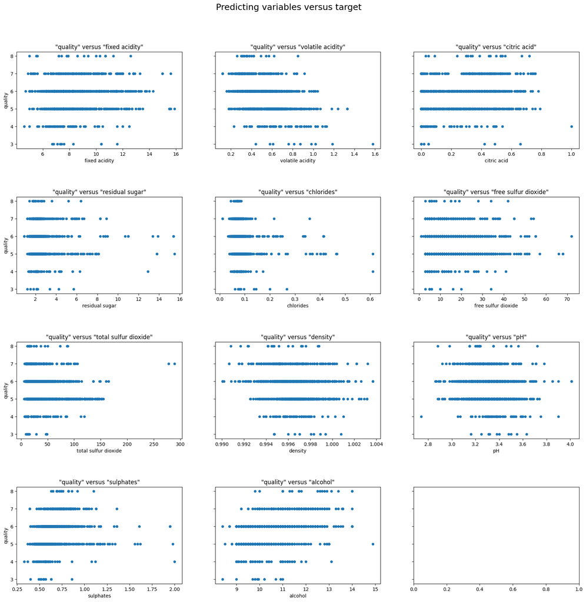

```python
try:
      ncols=X.shape[1]//4+1
      import math
      nrows = math.ceil((data.shape[1]-1)/ncols)
      figwidth = ncols * 7
      figheigth = nrows*5
      fig, axs = plt.subplots(nrows=nrows, ncols=ncols, figsize=(figwidth, figheigth),sharey=True)
      plt.subplots_adjust(hspace=0.5)
      fig.suptitle("Predicting variables versus target", fontsize=18, y=0.95)

      for c, ax in zip(data.drop(target,axis=1).columns,axs.ravel()):
          data.sort_values(by=c).plot.scatter(x=c,y=target
                                          , title = '"{}" versus "{}"'.format(target,c)
                                          , ax=ax)
  except: pass #anyway
```

Split the data

```python
X_train, X_test, y_train, y_test = train_test_split(X,y,random_state=random_state, train_size=0.7)
  print('Training set and test set have {} and {} elements respectively'.format(X_train.shape[0],X_test.shape[0]))
```

```
Training set and test set have 1119 and 480 elements respectively
```

**Compute the regression considering all the predicting variables**

```python
# Create linear regression object
  linear_reg = linear_model.LinearRegression()

  # Train the model using the training set
  linear_reg.fit(X_train, y_train)

  R_square_train = linear_reg.score(X_train,y_train)
  R_square_test = linear_reg.score(X_test,y_test)

  print('R square obtain is :',R_square_train)
  print('R square obtain is :',R_square_test)

  mean0=mean_squared_error(linear_reg.predict(X_test),y_test,squared=False)
  mean0
```

```
R square obtain is : 0.3732759065136658
  R square obtain is : 0.31860057760266647
```

```
0.6439937591429797
```

```python
# Show the coefficients of the predicting variables
  _,p=f_regression(X,y)
  p_values_check = np.where(p < 0.05, 'significant','non-sign.')
  coff_p=pd.DataFrame({'Variable': X.columns, 'Coefficient': linear_reg.coef_,'p-value': p_values_check})
  coff_p.head(X.shape[1])
```

|  | Variable | Coefficient | p-value |
| --- | --- | --- | --- |
| 0 | fixed acidity | 0.045853 | significant |
| 1 | volatile acidity | -1.176403 | significant |
| 2 | citric acid | -0.287778 | significant |
| 3 | residual sugar | 0.016492 | non-sign. |
| 4 | chlorides | -1.806362 | significant |
| 5 | free sulfur dioxide | 0.006071 | significant |
| 6 | total sulfur dioxide | -0.003779 | significant |
| 7 | density | -32.615524 | significant |
| 8 | pH | -0.375065 | significant |
| 9 | sulphates | 0.887110 | significant |
| 10 | alcohol | 0.267135 | significant |

I don't even try to do it with ZZFeature on VQR

**I have too much features: try to remove non-sign value and low correlated ones**

```python
# Since I'm interested in having a small number of qbits after that, let's try to remove non-sign columns and ones that have coeff. near to 0

  to_rem = coff_p[(coff_p['Coefficient']>=-0.05) & (coff_p['Coefficient']<=0.05)].sort_values('Coefficient',ascending=False)
  print('\nWe could remove all these {} columns: {}'.format(len(to_rem),to_rem.iloc[:,:1].to_numpy().ravel()))
  X1 = X.drop(columns=to_rem.iloc[:,:1].to_numpy().ravel())

  # And we do the test again
  X1_train, X1_test = train_test_split(X1,random_state=random_state, train_size=0.7)
  linear_reg_reduced = linear_model.LinearRegression()
  linear_reg_reduced.fit(X1_train, y_train)
  _,p=f_regression(X1,y)
  p_values_check = np.where(p < 0.05, 'significant','non-sign.')
  coff_p=pd.DataFrame({'Variable': X1.columns, 'Coefficient': linear_reg_reduced.coef_,'p-value': p_values_check})
  coff_p.head(X1.shape[1])
```

```
  We could remove all these 4 columns: ['fixed acidity' 'residual sugar' 'free sulfur dioxide'
   'total sulfur dioxide']
```

|  | Variable | Coefficient | p-value |
| --- | --- | --- | --- |
| 0 | volatile acidity | -1.296411 | significant |
| 1 | citric acid | -0.341137 | significant |
| 2 | chlorides | -1.779437 | significant |
| 3 | density | 6.540210 | significant |
| 4 | pH | -0.601877 | significant |
| 5 | sulphates | 0.820373 | significant |
| 6 | alcohol | 0.321450 | significant |

```python
R_square_7q_train = linear_reg_reduced.score(X1_train,y_train)
  R_square_7q_test = linear_reg_reduced.score(X1_test,y_test)

  print('R square obtain is :',R_square_7q_train)
  print('R square obtain is :',R_square_7q_test)

  mean0_7=mean_squared_error(linear_reg_reduced.predict(X1_test),y_test,squared=False)
  mean0_7
```

```
R square obtain is : 0.35880250217033716
  R square obtain is : 0.3202360836824537
```

```
0.6432204326300612
```

even better; let's do again... i want no more tha 5 qbits

```python
coff_p_2=pd.DataFrame({'Variable': X1.columns, 'Coefficient': linear_reg_reduced.coef_,'p-value': p_values_check})
  to_rem_2 = coff_p[(coff_p_2['Coefficient']>=-0.99) & (coff_p_2['Coefficient']<=0.99)].sort_values('Coefficient',ascending=False)
  print('\nWe could remove all these {} columns: {}'.format(len(to_rem_2),to_rem_2.iloc[:,:1].to_numpy().ravel()))
  X2 = X1.drop(columns=to_rem_2.iloc[:,:1].to_numpy().ravel())

  X2_train, X2_test = train_test_split(X2,random_state=random_state, train_size=0.7)
  linear_reg_reduced_2 = linear_model.LinearRegression()
  linear_reg_reduced_2.fit(X2_train, y_train)
  _,p=f_regression(X2,y)
  p_values_check = np.where(p < 0.05, 'significant','non-sign.')
  coff_p2=pd.DataFrame({'Variable': X2.columns, 'Coefficient': linear_reg_reduced_2.coef_,'p-value': p_values_check})
  coff_p2.head(X1.shape[1])
```

```
  We could remove all these 4 columns: ['sulphates' 'alcohol' 'citric acid' 'pH']
```

|  | Variable | Coefficient | p-value |
| --- | --- | --- | --- |
| 0 | volatile acidity | -1.813066 | significant |
| 1 | chlorides | -1.357819 | significant |
| 2 | density | -67.846736 | significant |

```python
R_square_3q_train = linear_reg_reduced_2.score(X2_train,y_train)
  R_square_3q_test = linear_reg_reduced_2.score(X2_test,y_test)

  print('R square obtain is :',R_square_3q_train)
  print('R square obtain is :',R_square_3q_test)
  mean0_3=mean_squared_error(linear_reg_reduced_2.predict(X2_test),y_test,squared=False)
  mean0_3
```

```
R square obtain is : 0.20155534312825074
  R square obtain is : 0.1351628118382705
```

```
0.7255176065766589
```

```python
print(f"Model                           | R2-Train   | R2-test    | RMSE       |")
  print(f"LRM, all features               | {R_square_train:10.4f} | {R_square_test:10.4f} | {mean0:10.2f} |")
  print(f"------------------------------------------------------------------------")
  print(f"LRM, 7 features                 | {R_square_7q_train:10.4f} | {R_square_7q_test:10.4f} | {mean0_7:10.2f} |")
  print(f"------------------------------------------------------------------------")
  print(f"LRM, 3 features                 | {R_square_3q_train:10.4f} | {R_square_3q_test:10.4f} | {mean0_3:10.2f} |")
```

```
Model                           | R2-Train   | R2-test    | RMSE       |
  LRM, all features               |     0.3733 |     0.3186 |       0.64 |
  ------------------------------------------------------------------------
  LRM, 7 features                 |     0.3588 |     0.3202 |       0.64 |
  ------------------------------------------------------------------------
  LRM, 3 features                 |     0.2016 |     0.1352 |       0.73 |
```

#### QML section multivariate

It is essential before start, to trasform target value to fit the interval [-1,1]

```python
y_scaler = MinMaxScaler(feature_range=(-1,1))
  y_scaler.fit(y.to_numpy().reshape(-1,1))
  y_train_t = y_scaler.transform(y_train.to_numpy().reshape(-1,1))
  y_test_t = y_scaler.transform(y_test.to_numpy().reshape(-1,1))

  x_scaler = MinMaxScaler(feature_range=(-1,1))
  x_scaler.fit(X1.to_numpy())
  x1_train_t = x_scaler.transform(X1_train.to_numpy())
  x1_test_t = x_scaler.transform(X1_test.to_numpy())
```

[output not shown]

Remap feature and labels

```python
train_features,test_features,train_labels,test_labels = (x1_train_t,
                                                           x1_test_t,
                                                           y_train_t,
                                                           y_test_t)
  num_features = X1.shape[1]
```

```python
from qiskit.circuit.library import ZZFeatureMap, PauliFeatureMap, StatePreparation
  from qiskit.circuit.library import RealAmplitudes

  feature_map = PauliFeatureMap(feature_dimension=num_features)
  ansatz = RealAmplitudes(num_qubits=num_features, reps=3)

  #feature_map.decompose().draw(output="mpl", fold=20)
  #ansatz.decompose().draw(output="mpl", fold=20)
```

```python
from matplotlib import pyplot as plt
  from IPython.display import clear_output
  objective_func_vals = []
  plt.rcParams["figure.figsize"] = (12, 6)


  def callback_graph(weights, obj_func_eval):
      clear_output(wait=True)
      objective_func_vals.append(obj_func_eval)
      plt.title("Objective function value against iteration")
      plt.xlabel("Iteration")
      plt.ylabel("Objective function value")
      plt.plot(range(len(objective_func_vals)), objective_func_vals)
      plt.show()
```

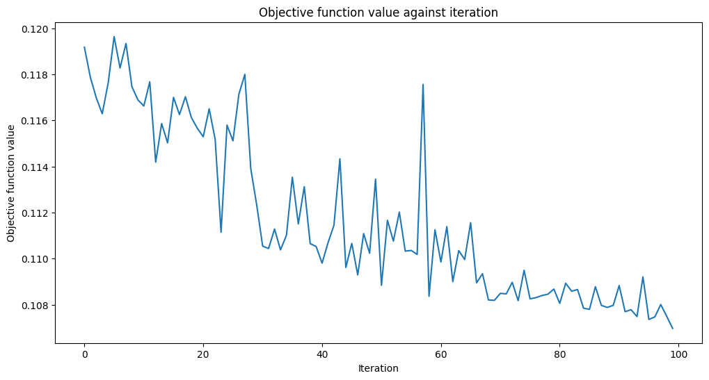

```
Training time: 2751 seconds
```

```python
import time
  from qiskit_machine_learning.algorithms.regressors import VQR
  from qiskit.algorithms.optimizers import COBYLA

  vqr1 = VQR(
      feature_map=feature_map,
      ansatz=ansatz,
      optimizer=COBYLA(maxiter=100),
      callback=callback_graph,
  )

  # clear objective value history
  objective_func_vals = []

  start = time.time()
  vqr1.fit(train_features, train_labels)
  elapsed = time.time() - start

  print(f"Training time: {round(elapsed)} seconds")
```

```python
train_score_q7 = vqr1.score(train_features, train_labels)
  test_score_q7 = vqr1.score(test_features, test_labels)

  print(f"Quantum VQR on the training dataset: {train_score_q7:.2f}")
  print(f"Quantum VQR on the test dataset:     {test_score_q7:.2f}")


  y_predicted=vqr1.predict(test_features)
  mean1=mean_squared_error(y_test,y_predicted,squared=False)
  mean1
```

```
Quantum VQR on the training dataset: 0.00
  Quantum VQR on the test dataset:     -0.04
```

```
5.647621900723062
```

**Not really good performance.**

𝑅2 compares the fit of the chosen model with that of a horizontal straight line (the null hypothesis). If the chosen model fits worse than a horizontal line, then 𝑅2 is negative.

Try to reduce features (7 -> 3) like we did on CLM, without loosing relevant information

```python
train_features,test_features,train_labels,test_labels = (X2_train.to_numpy(),
                                                           X2_test.to_numpy(),
                                                           y_train_t,
                                                           y_test_t)
  num_features = X2.shape[1]
  feature_map=ZZFeatureMap(feature_dimension=num_features)
  ansatz=RealAmplitudes(num_qubits=num_features)
```

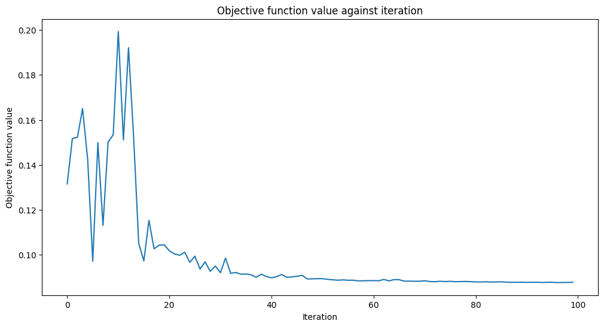

```
Training time: 719 seconds
```

```python
from qiskit.algorithms.optimizers import L_BFGS_B
  from qiskit_machine_learning.algorithms.regressors import VQR
  import time

  vqr2 = VQR(
      feature_map=feature_map,
      ansatz=ansatz,
      optimizer=COBYLA(maxiter=100),
      callback=callback_graph,
  )

  objective_func_vals = []

  start = time.time()
  vqr2.fit(train_features, train_labels)
  elapsed = time.time() - start

  print(f"Training time: {round(elapsed)} seconds")
```

```python
train_score_q3 = vqr2.score(train_features, train_labels)
  test_score_q3 = vqr2.score(test_features, test_labels)

  print(f"Quantum VQR on the training dataset: {train_score_q3:.2f}")
  print(f"Quantum VQR on the test dataset:     {test_score_q3:.2f}")

  y_predicted=vqr2.predict(test_features)
  mean2=mean_squared_error(y_test,y_predicted,squared=False)
  mean2
```

```
Quantum VQR on the training dataset: 0.18
  Quantum VQR on the test dataset:     0.10
```

```
5.570102525363638
```

**Little better**

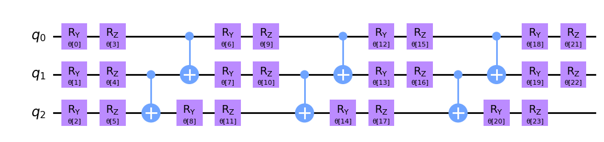

```python
from qiskit.circuit.library import EfficientSU2

  ansatz= EfficientSU2(num_qubits=3, reps=3)
  ansatz.decompose().draw(output="mpl", fold=20)
```

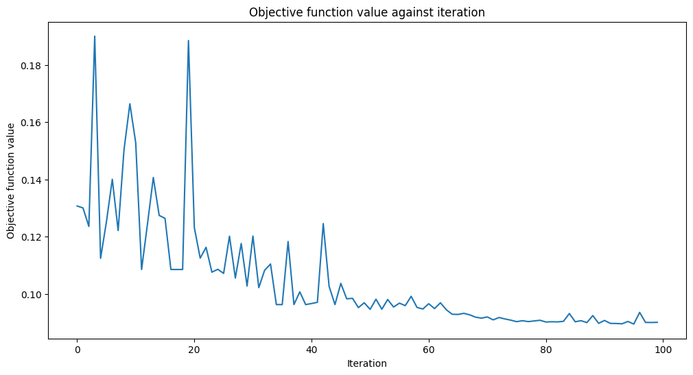

```
Training time: 707 seconds
```

```python
vqr3 = VQR(
      feature_map=feature_map,
      ansatz=EfficientSU2(num_qubits=num_features, reps=2),
      optimizer=COBYLA(maxiter=100),
      callback=callback_graph,
  )

  # clear objective value history
  objective_func_vals = []

  start = time.time()
  vqr3.fit(train_features, train_labels)
  elapsed = time.time() - start

  print(f"Training time: {round(elapsed)} seconds")
```

```python
train_score_q3_eff = vqr3.score(train_features, train_labels)
  test_score_q3_eff = vqr3.score(test_features, test_labels)

  print(f"Quantum VQC on the training dataset using EfficientSU2: {train_score_q3_eff:.2f}")
  print(f"Quantum VQC on the test dataset using EfficientSU2:     {test_score_q3_eff:.2f}")


  y_predicted=vqr3.predict(test_features)
  mean3=mean_squared_error(y_test,y_predicted,squared=False)
  mean3
```

```
Quantum VQC on the training dataset using EfficientSU2: 0.16
  Quantum VQC on the test dataset using EfficientSU2:     0.04
```

```
5.5747060691979415
```

**I also tried another optimizer, that seem more suitable for linear Regression**

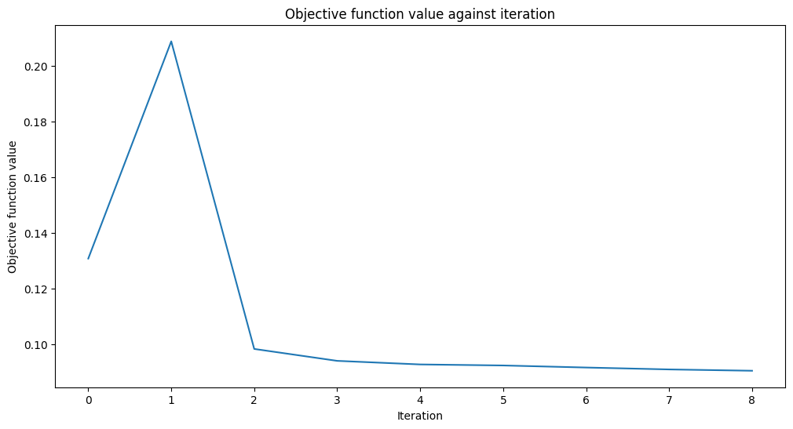

```
Training time: 1060 seconds
```

```python
vqr4 = VQR(
      feature_map=feature_map,
      ansatz=RealAmplitudes(num_qubits=num_features),
      optimizer=L_BFGS_B(maxiter=7),
      callback=callback_graph,
  )

  # clear objective value history
  objective_func_vals = []

  start = time.time()
  vqr4.fit(train_features, train_labels)
  elapsed = time.time() - start

  print(f"Training time: {round(elapsed)} seconds")
```

```python
train_score_q3_eff_LB = vqr4.score(train_features, train_labels)
  test_score_q3_eff_LB = vqr4.score(test_features, test_labels)

  print(f"Quantum VQC on the training dataset using EfficientSU2: {train_score_q3_eff_LB:.2f}")
  print(f"Quantum VQC on the test dataset using EfficientSU2:     {test_score_q3_eff_LB:.2f}")

  y_predicted=vqr4.predict(test_features)
  mean4=mean_squared_error(y_test,y_predicted,squared=False)
  mean4
```

[output not shown]

```
5.551444670026557
```

#### Wrap-up

```python
print(f"Model                           | Test Score | Train Score | RMSE      |")
  print(f"LRM, all features               | {R_square_train:10.2f} | {R_square_test:10.2f} | {mean0:10.3f} |")
  print(f"------------------------------------------------------------------------")
  print(f"LRM, 7 features                 | {R_square_7q_train:10.2f} | {R_square_7q_test:10.2f} | {mean0_7:10.3f} |")
  print(f"VQR, 7 features, RealAmplitudes | {train_score_q7:10.2f} | {test_score_q7:10.2f} | {mean1:10.3f} |")
  print(f"------------------------------------------------------------------------")
  print(f"LRM, 3 features                 | {R_square_3q_train:10.2f} | {R_square_3q_test:10.2f} | {mean0_3:10.3f} |")
  print(f"VQR, 3 features, RealAmplitudes | {train_score_q3:10.2f} | {test_score_q3:10.2f} | {mean2:10.3f} |")
  print(f"VQR, 3 features, EfficientSU2   | {train_score_q3_eff:10.2f} | {test_score_q3_eff:10.2f} | {mean3:10.3f} |")
  print(f"VQR, 3 features, RA & L_BFGS_B  | {train_score_q3_eff_LB:10.2f} | {test_score_q3_eff_LB:10.2f} | {mean4:10.3f} |")
```

[output not shown]

#### Conclusion

With all the features, i didn't even try to run it on the QML counterpart due to lack of performance on my computer.

Trying to change the ansats to **EfficientSU2** do not have improved performance of the model, and the train-test results are ambiguous

With another optimizer **L_BFGS_B** i reached a better performance. Maybe it is the best cost benefit ratio.

To conclude, I got no remarkable results with QML (not better than CML) but not that bad either. Perhaps also due to the few pre-processing performed on the data and my lack of time (i cannot perform test of 40min each).